# Task 7.2

Hannes Guth

2022-11-06

## Data exploration

Before the tasks can be addressed, the data has to be explored.  
As a first step, necessary packages will be loaded.

```r
library(naniar) # handling missing values
library(fastDummies) # package to create dummy-variables
library(data.table) # package for handling data in a datatable
library(ggplot2) # package for plots
library(class) # allows to get a numerical output variable
library(dplyr) # package for piping
library(FNN) # allows to get a list of nearest neighbours
library(caret) # allow the training for classification problems
```

```r
bank.df <- read.csv("UniversalBank.csv") # load dataframe
```

```r
dim(bank.df) # number of rows/observations and variables
```

```
## [1] 5000   14
```

The dataframe has 14 variables and 5000 observations.

```r
str(bank.df) # returns the type and the head of the columns/variables
```

```
## 'data.frame':    5000 obs. of  14 variables:
##  $ ID                : int  1 2 3 4 5 6 7 8 9 10 ...
##  $ Age               : int  25 45 39 35 35 37 53 50 35 34 ...
##  $ Experience        : int  1 19 15 9 8 13 27 24 10 9 ...
##  $ Income            : int  49 34 11 100 45 29 72 22 81 180 ...
##  $ ZIP.Code          : int  91107 90089 94720 94112 91330 92121 91711 93943 90089 93023 ...
##  $ Family            : int  4 3 1 1 4 4 2 1 3 1 ...
##  $ CCAvg             : num  1.6 1.5 1 2.7 1 0.4 1.5 0.3 0.6 8.9 ...
##  $ Education         : int  1 1 1 2 2 2 2 3 2 3 ...
##  $ Mortgage          : int  0 0 0 0 0 155 0 0 104 0 ...
##  $ Personal.Loan     : int  0 0 0 0 0 0 0 0 0 1 ...
##  $ Securities.Account: int  1 1 0 0 0 0 0 0 0 0 ...
##  $ CD.Account        : int  0 0 0 0 0 0 0 0 0 0 ...
##  $ Online            : int  0 0 0 0 0 1 1 0 1 0 ...
##  $ CreditCard        : int  0 0 0 0 1 0 0 1 0 0 ...
```

Except one variable (CCAvg), all variables are in integer-form.

```r
summary(bank.df) # creates a summary for all variables
```

```
##        ID            Age          Experience       Income          ZIP.Code
##  Min.   :   1   Min.   :23.00   Min.   :-3.0   Min.   :  8.00   Min.   : 9307
##  1st Qu.:1251   1st Qu.:35.00   1st Qu.:10.0   1st Qu.: 39.00   1st Qu.:91911
##  Median :2500   Median :45.00   Median :20.0   Median : 64.00   Median :93437
##  Mean   :2500   Mean   :45.34   Mean   :20.1   Mean   : 73.77   Mean   :93153
##  3rd Qu.:3750   3rd Qu.:55.00   3rd Qu.:30.0   3rd Qu.: 98.00   3rd Qu.:94608
##  Max.   :5000   Max.   :67.00   Max.   :43.0   Max.   :224.00   Max.   :96651
##      Family          CCAvg          Education        Mortgage
##  Min.   :1.000   Min.   : 0.000   Min.   :1.000   Min.   :  0.0
##  1st Qu.:1.000   1st Qu.: 0.700   1st Qu.:1.000   1st Qu.:  0.0
##  Median :2.000   Median : 1.500   Median :2.000   Median :  0.0
##  Mean   :2.396   Mean   : 1.938   Mean   :1.881   Mean   : 56.5
##  3rd Qu.:3.000   3rd Qu.: 2.500   3rd Qu.:3.000   3rd Qu.:101.0
##  Max.   :4.000   Max.   :10.000   Max.   :3.000   Max.   :635.0
##  Personal.Loan   Securities.Account   CD.Account         Online
##  Min.   :0.000   Min.   :0.0000     Min.   :0.0000   Min.   :0.0000
##  1st Qu.:0.000   1st Qu.:0.0000     1st Qu.:0.0000   1st Qu.:0.0000
##  Median :0.000   Median :0.0000     Median :0.0000   Median :1.0000
##  Mean   :0.096   Mean   :0.1044     Mean   :0.0604   Mean   :0.5968
##  3rd Qu.:0.000   3rd Qu.:0.0000     3rd Qu.:0.0000   3rd Qu.:1.0000
##  Max.   :1.000   Max.   :1.0000     Max.   :1.0000   Max.   :1.0000
##    CreditCard
##  Min.   :0.000
##  1st Qu.:0.000
##  Median :0.000
##  Mean   :0.294
##  3rd Qu.:1.000
##  Max.   :1.000
```

Due to the different dimensions of variables, one can see that the variables are not normalised yet. This needs to be done later on in attempt to run knn-methods.  
One can also see that the minimum value of experience is negative even though this column should denote years, which can not be negative.

```r
count = 0 # set a new counter to 0
for (i in 1:nrow(bank.df[])){ # for all observations in the table
  if (bank.df[i,3] < 0){ # if there is an observation of negative years
    count <- count + 1} # add 1 to the counter
}
count # print the counter
```

```
## [1] 52
```

```r
count/nrow(bank.df[]) # calculate the number ob negative year observation to the overall observations
```

```
## [1] 0.0104
```

This issue affects 52 values, that is roughly 1 % of the data. Without further information, one might assume that this can be a measure for experience in a special field where experience from another field might be hindering. It could also be years in prison or just false data, while this case seems unlikely regarding that 52 cases accumulate in only 3 negative years. Because of this, these data will be kept.

```r
uniquevalues <- data.table("Name" = "", "Number" = numeric(14)) # new datable to get an overview about unique values of the variables
for (i in 1:14){
  uniquevalues[i,1] = colnames(bank.df)[i] # assigning the name
  uniquevalues[i,2] = length(unique(bank.df[,i])) # assigning the number
}
uniquevalues # show result
```

```
##                   Name Number
##  1:                 ID   5000
##  2:                Age     45
##  3:         Experience     47
##  4:             Income    162
##  5:           ZIP.Code    467
##  6:             Family      4
##  7:              CCAvg    108
##  8:          Education      3
##  9:           Mortgage    347
## 10:      Personal.Loan      2
## 11: Securities.Account      2
## 12:         CD.Account      2
## 13:             Online      2
## 14:         CreditCard      2
```

This table shows how many different observations there are in the dataset for each variable.  
The variables Personal.Loan, Security.Account, CD.Account, Online and CreditCard are binary. The other variables are either categorical or numeric.

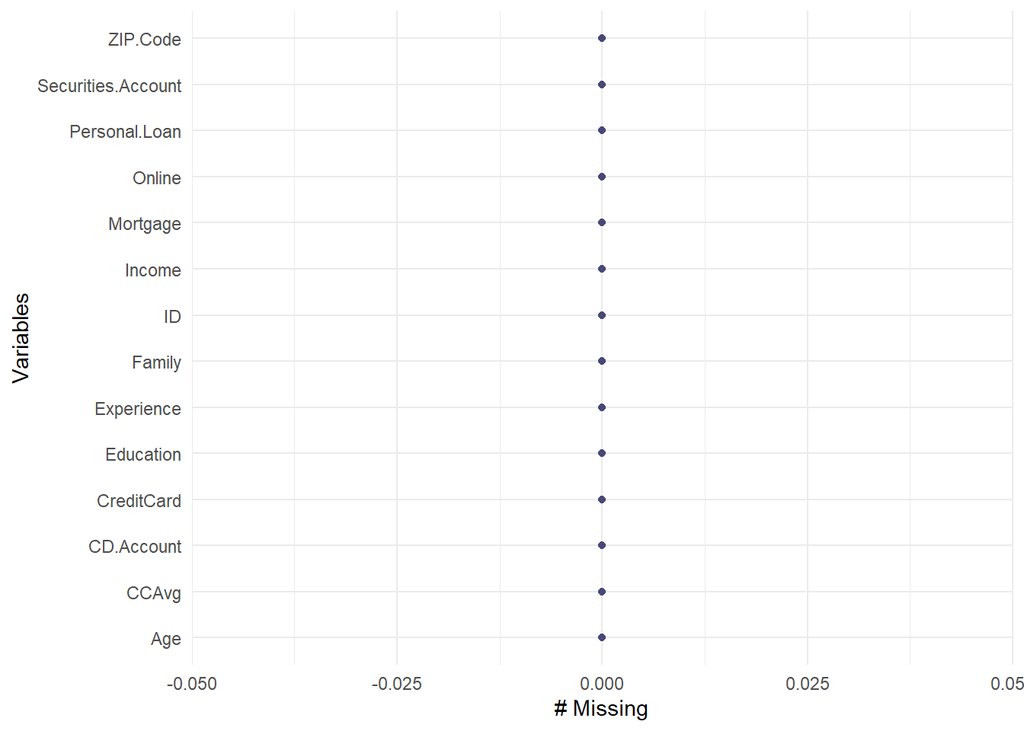

```r
gg_miss_var(bank.df) # plot graph for missing variables
```

In this dataset, there are no missing values.

## Preparation of data

Here, 0s and 1s will be replaced by more interpretable names and dummy variables will be created.

```r
# re-assigning names to substitute 0s and 1s, so that the result of knn later on will return something more interpretable than 0 and 1
for (i in 1:5000){
  if (bank.df[i,10] == 1){ # 1 stands for having accepted a personal loan and will be replaced by that
    bank.df[i,10] = "personal loan"
  }
  else{ # vice versa for 0
    bank.df[i,10] = "no personal loan"
  }
}
head(bank.df[,10])
```

```
## [1] "no personal loan" "no personal loan" "no personal loan" "no personal loan"
## [5] "no personal loan" "no personal loan"
```

In this step, education will be changed to dummy-variables since it is categorical.

```r
set.seed(1)
bank.dummy <- dummy_cols(bank.df, select_columns = "Education") # creating dummies for Education
bank.df <- bank.dummy %>% select(c(2:4,6,7,9:17)) # selecting only the necessary columns using the pipe operator
```

## a)

#### The approach to this and the upcoming tasks in 7.2 will in parts follow the ideas proposed in Shmueli et al (2018), pp. 176-179.

The accepting or not-accepting a loan of a customer with special characteristics shall be estimated by the use of knn.  
At first, the data will be split into a training- and a validation set.

```r
set.seed(1) # for reproducability of the random sampling, use set.seed(1)
trainIndex <- sample(row.names(bank.df), 0.6*dim(bank.df)[1]) # splitting indices in to 60 % (and the rest)
validIndex <- setdiff(row.names(bank.df), trainIndex) # valid gets the indices that train did not get

# assigning values to trainDF and validDF according to their assigned indices
# assigning values from bank.df respective to the already assigned indices
trainDF <- bank.df[trainIndex, ]
validDF <- bank.df[validIndex, ]

# assigning values to the entitity that shall be estimated by knn
# due to the upcoming process of normalising, the new entity will be attached to trainDF so that it can be normalised together with all the other data. This makes it necessary to arbitrarily insert a value for Personal.Loan.
newDF <- data.frame(Age = 40, Experience = 10, Income = 84, Family = 2, CCAvg = 2, Mortgage = 0, Personal.Loan = "personal loan", Securities.Account = 0, CD.Account = 0, Online = 1, CreditCard = 1, Education_1 = 0, Education_2 = 1, Education_3 = 0)

# appending the new entitity to trainDF in order to create a new dataframe and normalise it will all the other values
trainDF[nrow(trainDF) + 1, ] <- newDF
# creating a new dataframe, trainDF2 with contents of trainDF
trainDF2 <- trainDF
# delete the added row from trainDF, trainDF will be the same as it has been before adding the new entity
trainDF <- trainDF[-3001, ]

# creating new dataframes to store later on the normalised data, putting values in, here, has no effect but is rather a placeholder for the later upcoming normalised values
normalTrainDF <- trainDF
normalValidDF <- validDF
normalBankDF <- bank.df
```

The data needs to be normalised before knn can be applied.

```r
#normalising trainDF using preProcess, center shall center the data around a common average and scale scales the data so that a column with high values does not have more influence on the result than a column with small values
normalValues <- preProcess(trainDF[, c(1:6,8:14)], method = c("center", "scale"))

# normalising trainDF2, including the added row. trainDF and trainDF2 will be both normalised with "scale", so that there is no difference in the method itself. Nevertheless, using preProcess, one cannot simply extract the last row, so that another command was used, using the pipe operator.
trainDF2 <- trainDF2 %>% mutate_at(c(1:6,8:14), ~(scale(.) %>% as.vector)) #trainDF2 are the data to be normalised, mutate_at finally normalises the data, scale(.) is the actual normalisation and the result shall be a vector

newDF <- trainDF2[nrow(trainDF),] # from this take only the last row
newDF <- newDF[, c(1:6,8:14)] # take the relevant columns

head(normalTrainDF)
```

```
##      Age Experience Income Family CCAvg Mortgage    Personal.Loan
## 1017  30          5     69      1  0.80        0 no personal loan
## 4775  56         32     22      1  1.20        0 no personal loan
## 2177  41         14     51      3  2.33        0 no personal loan
## 1533  45         20     55      1  0.30        0 no personal loan
## 4567  24          0    131      1  5.40        0 no personal loan
## 2347  52         26     59      2  1.50      239 no personal loan
##      Securities.Account CD.Account Online CreditCard Education_1 Education_2
## 1017                  1          0      1          0           0           1
## 4775                  0          0      1          1           0           0
## 2177                  0          0      1          0           0           1
## 1533                  0          0      1          1           1           0
## 4567                  0          0      1          0           1           0
## 2347                  0          0      0          1           0           1
##      Education_3
## 1017           0
## 4775           1
## 2177           0
## 1533           0
## 4567           0
## 2347           0
```

```r
# predict the values for the normalDFs
normalTrainDF[, c(1:6,8:14)] <- predict(normalValues, trainDF[, c(1:6,8:14)])
normalValidDF[, c(1:6,8:14)] <- predict(normalValues, validDF[, c(1:6,8:14)])
normalBankDF[, c(1:6,8:14)] <- predict(normalValues, bank.df[, c(1:6,8:14)])
normalNewDF <- predict(normalValues, newDF)
```

Here, the knn-function from the FNN package is applied to finally predict the new entity.

```r
# deleting the column that is to predict
# use the knn function to predict the new entity
pred <- knn(train = normalTrainDF[, c(1:6,8:14)], test = normalNewDF, cl = normalTrainDF[, 7], k = 1) # use selected normalTrainDF as data to predict cl (for training), use normalNewDF as object on which the the prediction shall be executed, k = 1: Using only the closest nearest neighbour

# showing the result of the knn estimation
pred
```

```
## [1] no personal loan
## attr(,"nn.index")
##      [,1]
## [1,] 2425
## attr(,"nn.dist")
##          [,1]
## [1,] 3.999134
## Levels: no personal loan
```

The prediction is “no personal loan” for a customer with the values given above.

## b)

In this task it shall be examined which k provides the best balance between overfitting and ignoring the predictor information.

```r
accuracy <- data.frame(k = seq(1,14,1), accuracy = rep(0,14)) # create a new dataframe with ks to store the results
head(accuracy)
```

```
##   k accuracy
## 1 1        0
## 2 2        0
## 3 3        0
## 4 4        0
## 5 5        0
## 6 6        0
```

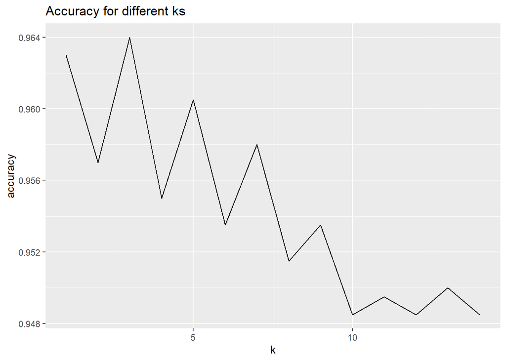

```r
for(i in 1:14){
  prediction <- knn(normalTrainDF[, c(1:6,8:14)], normalValidDF[, c(1:6,8:14)],
                  cl = normalTrainDF[, 7], k = i) # for each k from 0 to 14, execute the prediction
  accuracy[i, 2] <- confusionMatrix(prediction, as.factor(normalValidDF[, 7]))$overall[1] # assigning the accuracy-value to the respective k in the accuracy dataframe
}

accuracy <- as.data.table(accuracy) # use a datatable instead of dataframe
ggplot(accuracy, aes(x = k, y = accuracy)) + # create a ggplot with the values of k on the x-axis and the respective accuracy on the y-axis
  geom_line() + # shall be a lineplot
  labs(title = "Accuracy for different ks") # title
```

```r
accuracy <- accuracy[order(-accuracy),] # order descending
accuracy # display the results
```

```
##      k accuracy
##  1:  3   0.9640
##  2:  1   0.9630
##  3:  5   0.9605
##  4:  7   0.9580
##  5:  2   0.9570
##  6:  4   0.9550
##  7:  6   0.9535
##  8:  9   0.9535
##  9:  8   0.9515
## 10: 13   0.9500
## 11: 11   0.9495
## 12: 10   0.9485
## 13: 12   0.9485
## 14: 14   0.9485
```

## c)

In this task, a confusion matrix for k = 3 will be created.

```r
prediction <- knn(normalTrainDF[, c(1:6,8:14)], normalValidDF[, c(1:6,8:14)],
                cl = normalTrainDF[, 7], k = 3) # make the prediction as above but with k = 3 (optimal k) and for all aboservations that were assigned to normalValidDF

# use the function "confusionMatrix" and using factors of the relevant column
confMatr <- confusionMatrix(prediction, as.factor(normalValidDF[, 7])) #
confMatr # show the result
```

```
## Confusion Matrix and Statistics
##
##                   Reference
## Prediction         no personal loan personal loan
##   no personal loan             1786            63
##   personal loan                   9           142
##
##                Accuracy : 0.964
##                  95% CI : (0.9549, 0.9717)
##     No Information Rate : 0.8975
##     P-Value [Acc > NIR] : < 2.2e-16
##
##                   Kappa : 0.7785
##
##  Mcnemar's Test P-Value : 4.208e-10
##
##             Sensitivity : 0.9950
##             Specificity : 0.6927
##          Pos Pred Value : 0.9659
##          Neg Pred Value : 0.9404
##              Prevalence : 0.8975
##          Detection Rate : 0.8930
##    Detection Prevalence : 0.9245
##       Balanced Accuracy : 0.8438
##
##        'Positive' Class : no personal loan
##
```

## d)

Here, the previous classification with k = 1 shall be repeated with k = 3, the optimal k.

```r
predk3 <- knn(train = normalTrainDF[, c(1:6,8:14)], test = normalNewDF, cl = normalTrainDF[, 7], k = 3) # repeating the prediction with k = 3
predk3 # showing the result
```

```
## [1] no personal loan
## attr(,"nn.index")
##      [,1] [,2] [,3]
## [1,] 2425 1777  643
## attr(,"nn.dist")
##          [,1]     [,2]     [,3]
## [1,] 3.999134 4.134969 4.176633
## Levels: no personal loan
```

The result (“no personal loan”) did not change.

## e)

In this task, the data will be re-partitioned, this time in 3 different sets. Afterwards, the confusion matrices will be compared.

```r
trainIndex <- sample(row.names(bank.df), 0.5*dim(bank.df)[1]) # the first 50 percent of indices shall be assigned to train
train.e <- bank.df[trainIndex, ] # getting the respective data for the indices
restIndex <- setdiff(row.names(bank.df), trainIndex) # rest shall contain the indices that have not yet been used for train
rest.e <- bank.df[restIndex, ] # assigning values to rest.e
testIndex <- sample(row.names(rest.e), 0.6*dim(rest.e)[1]) # splitting the indices of rest into 60% for test.e and 40% for valid.e.
test.e <- bank.df[testIndex, ] # assigning values to test.e
validIndex <- setdiff(row.names(rest.e), testIndex) # valid gets the indices that have not yet been assigned
valid.e <- bank.df[validIndex, ] # valid.e is filled with values, respective to its assigned indices
```

For a quick test, the number of observations of the created sets will be set in a relation.

valid.e should be 2/3 of test.e. train.e should approximately equal the sum of valid.e and test.e.

```r
nrow(valid.e)/nrow(test.e) # calculating proportion between the validation- and the test set
```

```
## [1] 0.6666667
```

```r
nrow(train.e)/(nrow(valid.e) + nrow(test.e)) # calculating the proportion between the training set and the sum of the other 2 sets.
```

```
## [1] 1
```

The test delivered the expected results.  
Now again, normalisation of the new sets will be conducted.

```r
# normalising as above

# assigning values as kind of placeholders to new dataframes which will later contain the normalised values
normalTrain.e <- train.e
normalValid.e <- valid.e
normalTest.e <- test.e
normalBank.e <- bank.df

# apply center and scale to the train.df and safe it to normalValues
normalValues <- preProcess(train.e[, c(1:6,8:14)], method = c("center", "scale"))

# predict with normalValues will now be used to normalise the columns of the new datasets that are later on used to predict personal loan
normalTrain.e[, c(1:6,8:14)] <- predict(normalValues, train.e[, c(1:6,8:14)])
normalValid.e[, c(1:6,8:14)] <- predict(normalValues, valid.e[, c(1:6,8:14)])
normalTest.e[, c(1:6,8:14)] <- predict(normalValues, test.e[, c(1:6,8:14)])
normalBank.e[, c(1:6,8:14)] <- predict(normalValues, bank.df[, c(1:6,8:14)])
```

In this last chunk, the confusion matrices will be produced.

```r
# knn-prediction for valid
nearestNeighbours1 <- knn(train = normalTrain.e[, c(1:6,8:14)], test = normalValid.e[, c(1:6,8:14)], cl = normalTrain.e[, 7], k = 3)
# matrix for train and valid
confMatr <- confusionMatrix(nearestNeighbours1, as.factor(normalValid.e[, 7]))
confMatr
```

```
## Confusion Matrix and Statistics
##
##                   Reference
## Prediction         no personal loan personal loan
##   no personal loan              890            30
##   personal loan                   3            77
##
##                Accuracy : 0.967
##                  95% CI : (0.954, 0.9772)
##     No Information Rate : 0.893
##     P-Value [Acc > NIR] : < 2.2e-16
##
##                   Kappa : 0.8057
##
##  Mcnemar's Test P-Value : 6.011e-06
##
##             Sensitivity : 0.9966
##             Specificity : 0.7196
##          Pos Pred Value : 0.9674
##          Neg Pred Value : 0.9625
##              Prevalence : 0.8930
##          Detection Rate : 0.8900
##    Detection Prevalence : 0.9200
##       Balanced Accuracy : 0.8581
##
##        'Positive' Class : no personal loan
##
```

```r
# knn-prediction for test
nearestNeighbours2 <- knn(train = normalTrain.e[, c(1:6,8:14)], test = normalTest.e[, c(1:6,8:14)], cl = normalTrain.e[, 7], k = 3)
# matrix for train and test
confMatr <- confusionMatrix(nearestNeighbours2, as.factor(normalTest.e[, 7]))
confMatr
```

```
## Confusion Matrix and Statistics
##
##                   Reference
## Prediction         no personal loan personal loan
##   no personal loan             1358            57
##   personal loan                   7            78
##
##                Accuracy : 0.9573
##                  95% CI : (0.9458, 0.967)
##     No Information Rate : 0.91
##     P-Value [Acc > NIR] : 1.215e-12
##
##                   Kappa : 0.6873
##
##  Mcnemar's Test P-Value : 9.068e-10
##
##             Sensitivity : 0.9949
##             Specificity : 0.5778
##          Pos Pred Value : 0.9597
##          Neg Pred Value : 0.9176
##              Prevalence : 0.9100
##          Detection Rate : 0.9053
##    Detection Prevalence : 0.9433
##       Balanced Accuracy : 0.7863
##
##        'Positive' Class : no personal loan
##
```

High values for sensitivity and low values for specificity can still be observed.  
The accuracy for the validation dataset is a bit higher than for the test dataset. This has nothing to say because except the size of the sets, they should not differ systematically.

## References

### Books

Shmueli, G., Bruce, P., Yahav, I., Patel, N., Lichtendahl, K. (2018): Data Mining for Business Analytics. Wiley.

### Packages

Tierney N, Cook D, McBain M, Fay C (2021). *naniar: Data Structures, Summaries, and Visualisations for Missing Data*. R package version 0.6.1, https://CRAN.R-project.org/package=naniar.

Kaplan J (2020). *fastDummies: Fast Creation of Dummy (Binary) Columns and Rows from Categorical Variables*. R package version 1.6.3, https://CRAN.R-project.org/package=fastDummies.

Dowle M, Srinivasan A (2021). *data.table: Extension of `data.frame`*. R package version 1.14.2, https://CRAN.R-project.org/package=data.table.

H. Wickham. ggplot2: Elegant Graphics for Data Analysis. Springer-Verlag New York, 2016.

Venables, W. N. & Ripley, B. D. (2002) Modern Applied Statistics with S. Fourth Edition. Springer, New York. ISBN 0-387-95457-0

Wickham H, François R, Henry L, Müller K (2022). *dplyr: A Grammar of Data Manipulation*. R package version 1.0.10, https://CRAN.R-project.org/package=dplyr.

Beygelzimer A, Kakadet S, Langford J, Arya S, Mount D, Li S (2022). *FNN: Fast Nearest Neighbor Search Algorithms and Applications*. R package version 1.1.3.1, https://CRAN.R-project.org/package=FNN.

Kuhn M (2022). *caret: Classification and Regression Training*. R package version 6.0-93, https://CRAN.R-project.org/package=caret.